# Trump Tweet Project

Fengshou Liang

20/10/2020

As the US election approaches, we see President Donald Trump has been tweeting more often. In this project, I will be analyzing Trump’s tweet from 2016-01-01 to 2020-10-04. I will be looking at his tweeting pattern in terms of time and date, and hopefully I will come up with some interesting Trump’s tweeting pattern. This project is inspired by [David Robinson’s blog](http://varianceexplained.org/r/trump-tweets/) and [Nathan Taback’s report](http://utstat.toronto.edu/~nathan/teaching/sta4002/Class4/trumptweets-students.html). The data is collected from [here](http://www.trumptwitterarchive.com/).

# Data

The data is collected from Trump Tweet Archive created by Brendan Brown and I copied and pasted the data from 2016-01-01 to 2020-10-04 to txt file.

```r
library(data.table)
trump <- fread("C:/Users/sheri/Desktop/Data/trump.txt")
```

# Exploring the data

We notice that Trump used a variety of devices to access twitter. Apart from that, we find the tweet content are sometimes websites, which we are not interested in. So let’s first take a look at the devices Trump has used.

```r
library(dplyr)
trump %>% count(source) %>% arrange(desc(n))
```

```
##                   source     n
##  1:   Twitter for iPhone 24469
##  2:  Twitter for Android  2115
##  3:   Twitter Web Client   396
##  4: Twitter Media Studio   212
##  5:         Media Studio   156
##  6:          Twitter Ads    96
##  7:     Twitter for iPad    60
##  8:      Twitter Web App     7
##  9:            Instagram     2
## 10:            TweetDeck     2
## 11:      Mobile Web (M5)     1
## 12:            Periscope     1
```

In fact, the following graph shows a more detailed version of devices used in a time series.

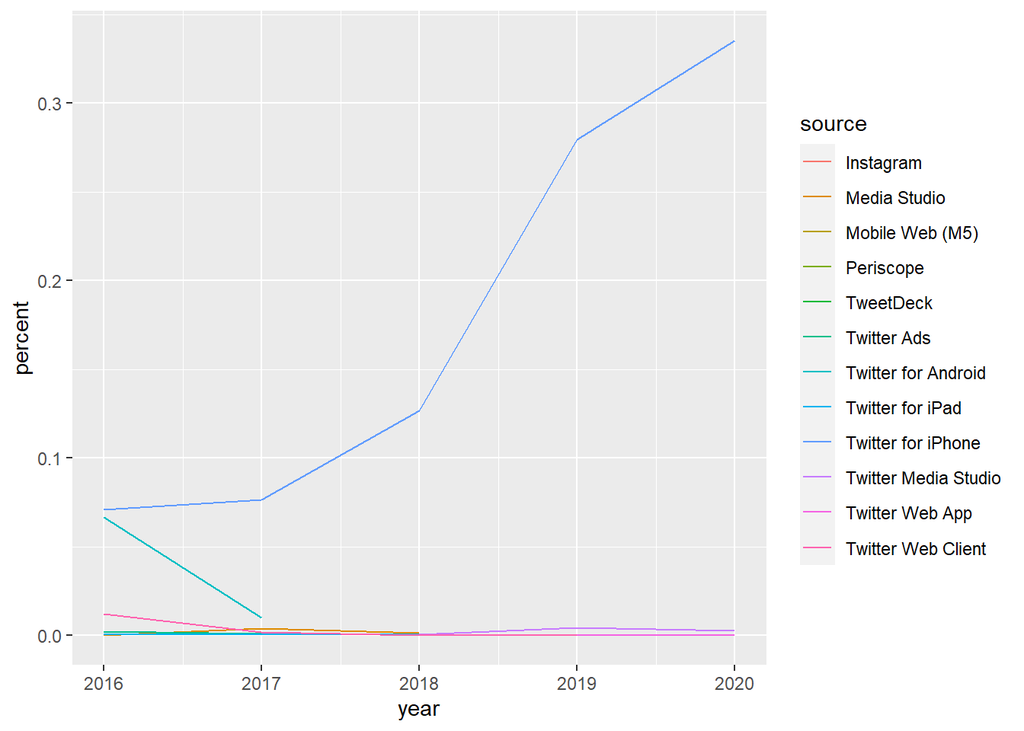

```r
library(ggplot2)
library(lubridate)
tweet <- trump %>%
  mutate(created_at =as.POSIXct(created_at, format = "%m-%d-%Y %H:%M:%S"))
tweet %>% count(source, year = year(created_at)) %>%
  mutate(percent = n / sum(n)) %>%
  ggplot(aes(year, percent, color = source)) +
  geom_line()
```

Here we notice that while the usage of most of devices stay unchanged, that of iPhone and Android changes dramatically. The change of iphone usage may be explained by Trump using Twitter more frequently with his phone but why is there a decrease in the use of Android? Now I will set a constraint on the timeline and investigate what happened from 2016 to 2017.

# Trump’s tweeting pattern

In fact, according to articles back in 2017, Trump has been reported posting slightly negative content with his Android device while positive tweets with iPhone. After such an exposure, Trump stopped using Android devices. Now let’s take a closer look and find the difference between them.

Since Trump’s last tweet with Android was on Mar.25, 2017, we are limiting his tweet to those before this date and categorize all other devices into “others” and focus on only iPhone and Android.

```r
library(stringr)
tweet_new <-
  tweet %>%
   mutate(created_at =as.POSIXct(created_at, format = "%m-%d-%Y %H:%M:%S")) %>%
  filter(created_at <= "2017-03-26") %>%
  mutate(source = ifelse(str_detect(source, "iPhone"), "iPhone", ifelse(str_detect(source, "Android"), "Android", "Others"))) %>%
  filter(source %in% c("iPhone", "Android"))
```

Some of Trump’s text contains an external link, so let’s take a look on how they distributed across two devices.

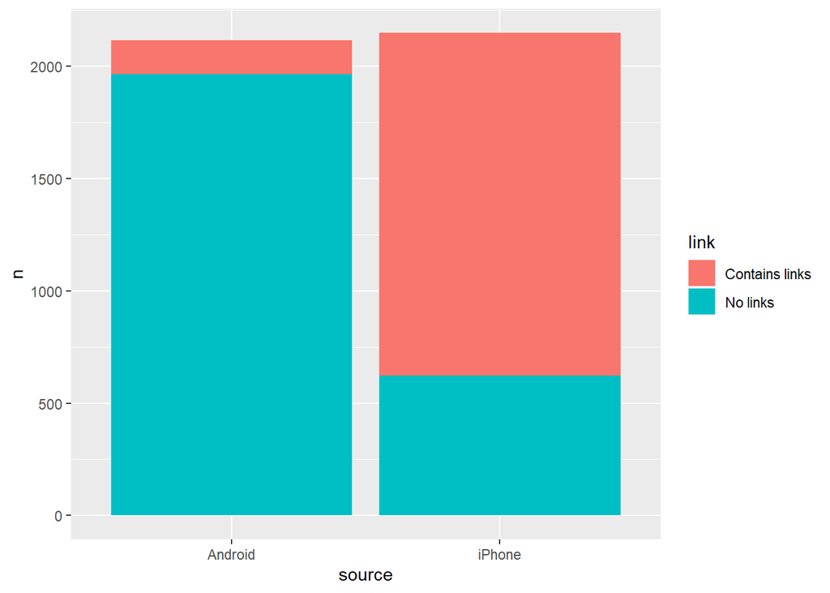

```r
tweet_link <-
  tweet_new %>%
  count(source, link = ifelse(str_detect(text, "http"), "Contains links", "No links"))

ggplot(tweet_link, aes(x=source, y=n, fill=link))+
  geom_bar(stat = "identity")
```

Similarly,the way he uses @ when referring to other people are also different but not as much as the one above.However, it appears that Trump @ people more frequently when he used Android phone.

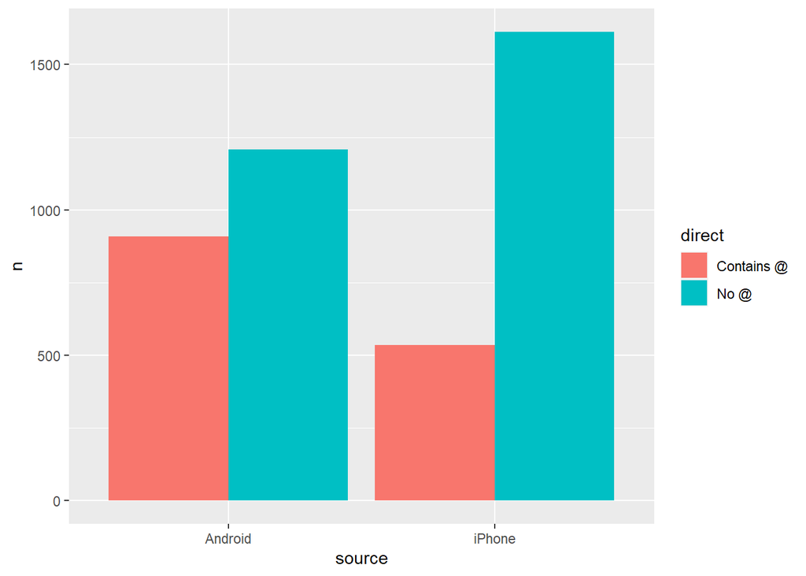

```r
tweet_new %>%
  count(source, direct = ifelse(str_detect(text, "@"), "Contains @", "No @")) %>%
  ggplot(aes(x=source, y=n, fill = direct)) +
  geom_bar(stat = "identity", position = "dodge")
```

# Tweet words and sentiments

```r
library(tidytext)
tweet_comparison <-
tweet_new %>%
  mutate(text = str_replace_all(text, "https://t.co/[A-Za-z0-9]", " ")) %>%
  unnest_tokens(word, text) %>%
  #With tokenization transform sentences into words
  filter(!word %in% stop_words$word & !word %in% c("rt","cruz", "amp", "â")) %>%
  #some words appears to be random so they need to be removed
  count(source, word) %>%
  arrange(source, desc(n))
```

Now we have found the words Trump used most frequently in different devices. We can plot them side by side for a visual comparison.

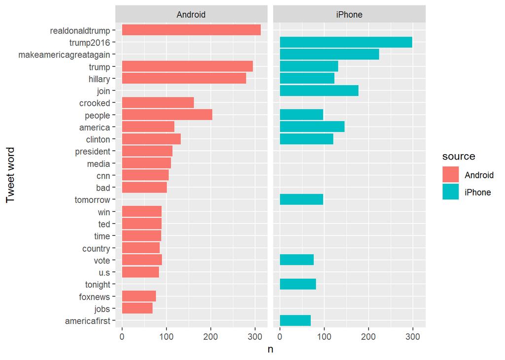

```r
tweet_comparison %>%
  top_n(30) %>%
  ggplot(aes(x=reorder(word, n), y=n, fill=source)) +
  geom_bar(stat = "identity") +
  xlab("Tweet word") +
  coord_flip() +
  facet_grid(. ~source)
```

```r
library(tidytext)
#sentiments is a dataframe containing a list of words with their sentiments (positive or negative).
head(sentiments)
```

```
## # A tibble: 6 x 2
##   word       sentiment
##   <chr>      <chr>
## 1 2-faces    negative
## 2 abnormal   negative
## 3 abolish    negative
## 4 abominable negative
## 5 abominably negative
## 6 abominate  negative
```

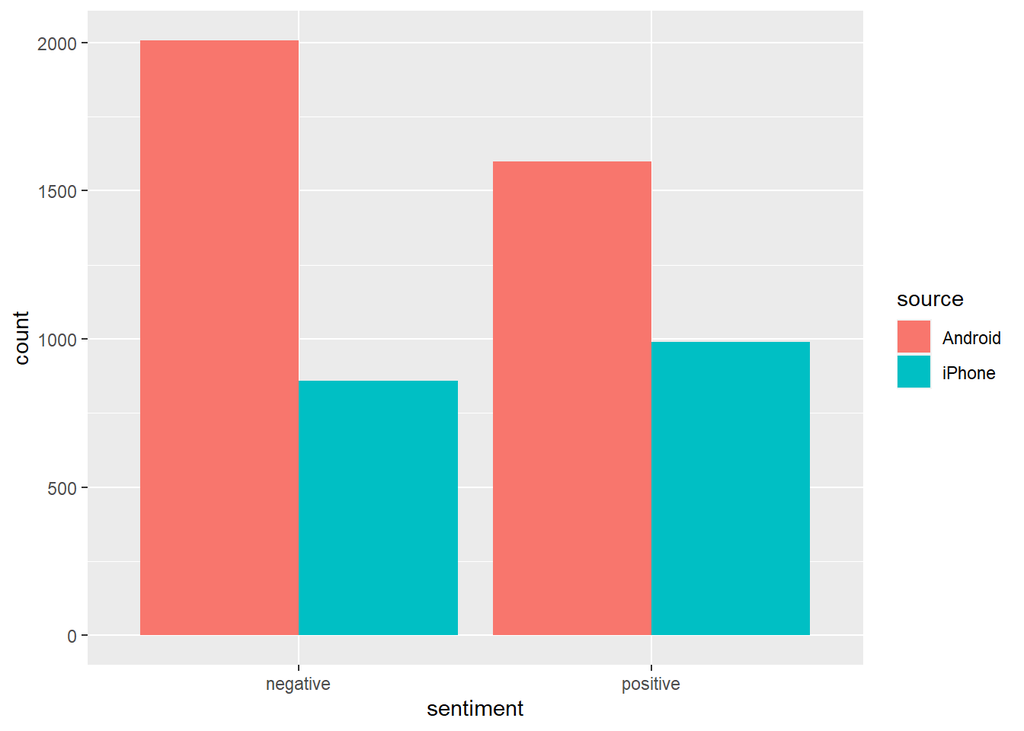

```r
tweet_comparison %>%
  inner_join(sentiments, by = "word") %>%
  group_by(sentiment, source) %>%
  summarise(count = sum(n))%>%
  ggplot(aes(sentiment, count, fill=source)) +
  geom_bar(stat = "identity", position = "dodge")
```

According to diagram above, when it comes to words associated with negative sentiments, Trump used his Android phone more often.

```r
# incomplete
#get number of Android negative word/total negative word per day
tweet_new %>%
  mutate(text = str_replace_all(text, "https://t.co/[A-Za-z0-9]", " ")) %>%
  unnest_tokens(word, text) %>%
  filter(!word %in% stop_words$word & !word %in% c("rt","cruz", "amp", "â")) %>%
  inner_join(sentiments, by = "word") %>%
  filter(sentiment == "negative") %>%
  group_by(date(created_at)) %>%
  mutate(sth = n())
```

```
## # A tibble: 2,865 x 10
## # Groups:   date(created_at) [377]
##    source created_at          retweet_count favorite_count is_retweet    id_str
##    <chr>  <dttm>                      <int>          <int> <lgl>          <dbl>
##  1 Andro~ 2017-03-25 14:37:52         22518         104321 FALSE      3.87e-252
##  2 Andro~ 2017-03-25 14:37:52         22518         104321 FALSE      3.87e-252
##  3 iPhone 2017-03-24 12:23:00         13364          61991 FALSE      3.67e-252
##  4 iPhone 2017-03-24 12:14:32         12566          68241 FALSE      3.67e-252
##  5 iPhone 2017-03-24 12:14:32         12566          68241 FALSE      3.67e-252
##  6 iPhone 2017-03-23 15:16:24         23258         117021 FALSE      3.52e-252
##  7 iPhone 2017-03-23 15:16:24         23258         117021 FALSE      3.52e-252
##  8 iPhone 2017-03-23 15:16:24         23258         117021 FALSE      3.52e-252
##  9 iPhone 2017-03-23 12:18:33         21324          94648 FALSE      3.50e-252
## 10 iPhone 2017-03-23 12:18:33         21324          94648 FALSE      3.50e-252
## # ... with 2,855 more rows, and 4 more variables: word <chr>, sentiment <chr>,
## #   `date(created_at)` <date>, sth <int>
```